# **Визуализация данных**

Лабораторная работа посвящена работе с библиотеками matplotlib и seaborn, позволяющими организовать построение графиков для имеющихся данных.

Рекомендуется выполнять лабораторную работу в Google Colab с использованием браузера. Если на вашем компьютере установлена Anaconda, вы можете скачать задание и выполнять его с использованием Anaconda.

В самом начале работы следует подключить нужные нам библиотеки

```python
import pandas as pd
import matplotlib.pyplot as plt
import numpy as np
import seaborn as sns
%matplotlib inline
```

Для выполнения последующих заданий в Google Colab потребуется подключить работу с гугл-диском, запустив следующую ячейку. (https://colab.research.google.com/drive/1DOwvT_j7OIkjZoNL4LwbXxDwmYUn0TLm?usp=sharing).

**Внимание! Если вы выполняете работу в Anaconda, следующую ячейку запускать не нужно!**

```python
# Я работаю в Anaconda
# from google.colab import drive
# drive.mount('/content/drive')
```

Перед выполнением следующих заданий вам нужно загрузить на свой гугл-диск файлы `pogoda.csv`, `tips.csv` и `Video_Games_Sales_as_at_22_Dec_2016.csv`. Файлы прикреплены к заданию.

**Если вы работаете в Anaconda, файлы нужно скачать на компьютер и поместить в папку, из которой вам будет удобно с ними работать.**

**Задание 1** Загрузите набор данных `pogoda.csv` и для каждого параметра постройте график. Требования:

- Цвет, стиль, толщина линии у графиков не должны повторяться.
- Каждый график должен быть в своей системе координат, как показано на рисунке 1.
- Добавьте названия, подписи осей и легенду.

**Примечание**: обратите внимание, что в таблице столбцы разделены символом табуляции. Для открытия необходимо использовать параметр `sep = '\t'`.

Рисунок 1 - Образец оформления графиков.

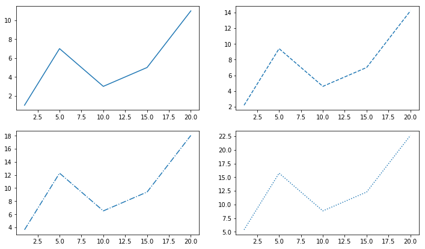

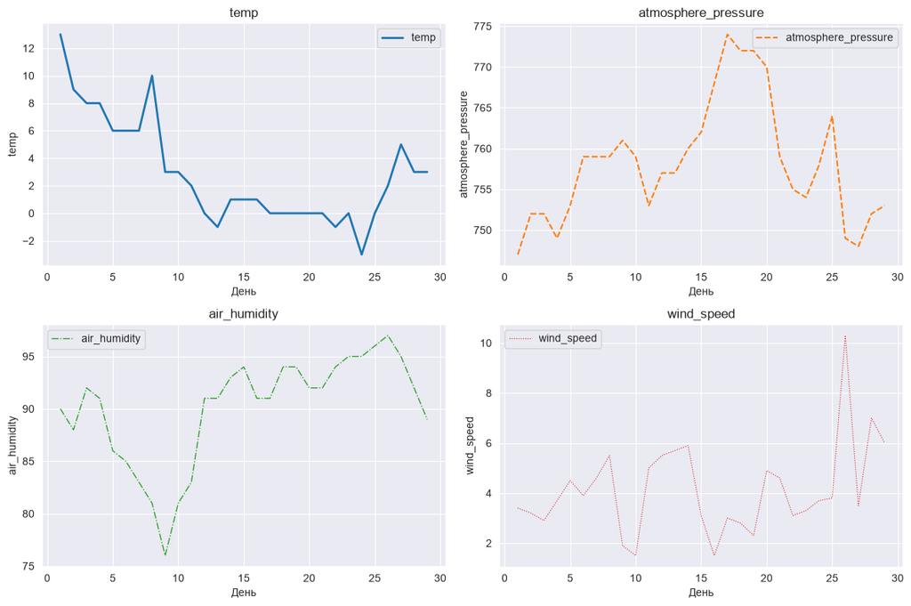

```python
# Решение задания 1
weather_data = pd.read_csv('pogoda.csv', sep='\t')

parameters = [column for column in weather_data.columns if column != 'day']
line_styles = ['-', '--', '-.', ':']
line_widths = [2, 1.5, 1, 0.8]
colors = plt.cm.tab10.colors

fig, axes = plt.subplots(2, 2, figsize=(12, 8))

for index, parameter in enumerate(parameters):
    row, col = divmod(index, 2)
    axes[row, col].plot(weather_data['day'], weather_data[parameter],
                        color=colors[index % len(colors)],
                        linestyle=line_styles[index % len(line_styles)],
                        linewidth=line_widths[index % len(line_widths)],
                        label=parameter)
    axes[row, col].set_title(parameter)
    axes[row, col].set_xlabel('День')
    axes[row, col].set_ylabel(parameter)
    axes[row, col].legend()

plt.tight_layout()
plt.show()
```

**Задание 2**. - Загрузите набор данных `tips.csv`. Выполните следующие задания:

1. С помощью библиотеки matplotlib постройте столбчатую диаграмму, где на оси X будут названия дней, а на оси Y сумма чаевых. Вам потребуется сгруппировать данные.
2. Сделайте так, чтобы названия дней располагались по диагонали.
3. Сделайте так, чтобы у каждого дня был свой уникальный цвет.

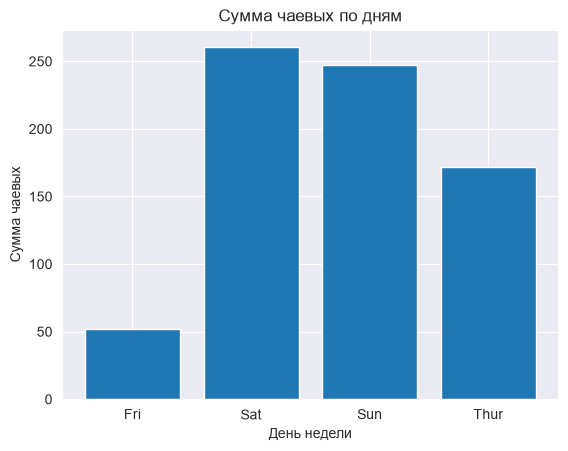

```python
# решение задания 2
# пункт 2.1
tips_data = pd.read_csv('tips.csv')

tips_by_day = tips_data.groupby('day')['tip'].sum()

plt.bar(tips_by_day.index, tips_by_day.values)
plt.xlabel('День недели')
plt.ylabel('Сумма чаевых')
plt.title('Сумма чаевых по дням')
plt.show()
```

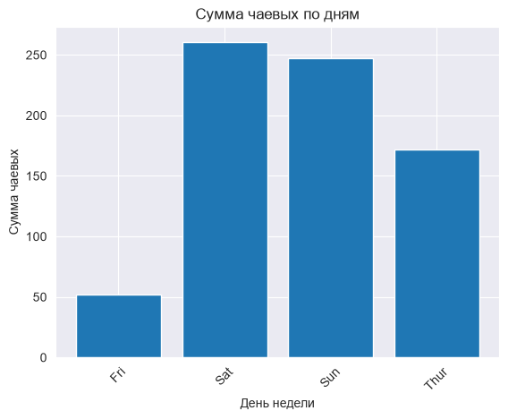

```python
# пункт 2.2
plt.bar(tips_by_day.index, tips_by_day.values)
plt.xlabel('День недели')
plt.ylabel('Сумма чаевых')
plt.title('Сумма чаевых по дням')
plt.xticks(rotation=45)
plt.show()
```

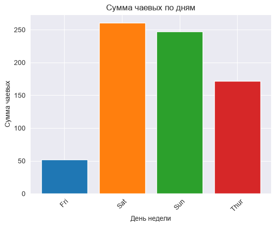

```python
# пункт 2.3
day_colors = plt.cm.tab10.colors[:len(tips_by_day)]

plt.bar(tips_by_day.index, tips_by_day.values, color=day_colors)
plt.xlabel('День недели')
plt.ylabel('Сумма чаевых')
plt.title('Сумма чаевых по дням')
plt.xticks(rotation=45)
plt.show()
```

**Задание 3**. Загрузите набор данных `Video_Games_Sales_as_at_22_Dec_2016.csv`

1. Удалите из него все записи с пропусками и выведите размеры датафрейма (должно получиться 6825 записи)
2. Удалите лишние параметры. У вас должны остаться: 'Name', 'Platform', 'Year_of_Release', 'Genre', 'NA_Sales', 'EU_Sales', 'JP_Sales','Other_Sales', 'Global_Sales', 'Critic_Score', 'Critic_Count', 'User_Score', 'User_Count', 'Rating'
3. Скорректируйте формат данных. Параметр 'User_Score' должен иметь формат 'float64', 'Year_of_Release' — 'int64', 'User_Count' — 'int64', 'Critic_Count' — 'int64'
4. Выведите полученную таблицу
5. По полученной таблице постройте график продаж видео игр в различных странах в зависимости от года (см. рис. 2).

Рисунок 2 - Примерный результат

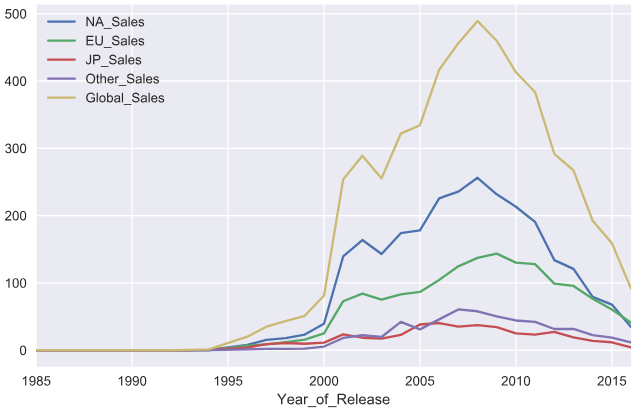

```python
# решение задания 3
# пункт 1
games_data = pd.read_csv('Video_Games_Sales_as_at_22_Dec_2016.csv')
games_data = games_data.dropna()
print(games_data.shape)
```

```
(6825, 16)
```

```python
# пункт 3.2
columns_to_keep = ['Name', 'Platform', 'Year_of_Release', 'Genre', 'NA_Sales',
                   'EU_Sales', 'JP_Sales', 'Other_Sales', 'Global_Sales',
                   'Critic_Score', 'Critic_Count', 'User_Score', 'User_Count', 'Rating']
games_data = games_data[columns_to_keep]
```

```python
# пункт 3.3
games_data['User_Score'] = games_data['User_Score'].astype('float64')
games_data['Year_of_Release'] = games_data['Year_of_Release'].astype('int64')
games_data['User_Count'] = games_data['User_Count'].astype('int64')
games_data['Critic_Count'] = games_data['Critic_Count'].astype('int64')
```

```python
# пункт 3.4
games_data
```

|  | Name | Platform | Year_of_Release | Genre | NA_Sales | EU_Sales | JP_Sales | Other_Sales | Global_Sales | Critic_Score | Critic_Count | User_Score | User_Count | Rating |
| --- | --- | --- | --- | --- | --- | --- | --- | --- | --- | --- | --- | --- | --- | --- |
| 0 | Wii Sports | Wii | 2006 | Sports | 41.36 | 28.96 | 3.77 | 8.45 | 82.53 | 76.0 | 51 | 8.0 | 322 | E |
| 2 | Mario Kart Wii | Wii | 2008 | Racing | 15.68 | 12.76 | 3.79 | 3.29 | 35.52 | 82.0 | 73 | 8.3 | 709 | E |
| 3 | Wii Sports Resort | Wii | 2009 | Sports | 15.61 | 10.93 | 3.28 | 2.95 | 32.77 | 80.0 | 73 | 8.0 | 192 | E |
| 6 | New Super Mario Bros. | DS | 2006 | Platform | 11.28 | 9.14 | 6.50 | 2.88 | 29.80 | 89.0 | 65 | 8.5 | 431 | E |
| 7 | Wii Play | Wii | 2006 | Misc | 13.96 | 9.18 | 2.93 | 2.84 | 28.92 | 58.0 | 41 | 6.6 | 129 | E |
| ... | ... | ... | ... | ... | ... | ... | ... | ... | ... | ... | ... | ... | ... | ... |
| 16667 | E.T. The Extra-Terrestrial | GBA | 2001 | Action | 0.01 | 0.00 | 0.00 | 0.00 | 0.01 | 46.0 | 4 | 2.4 | 21 | E |
| 16677 | Mortal Kombat: Deadly Alliance | GBA | 2002 | Fighting | 0.01 | 0.00 | 0.00 | 0.00 | 0.01 | 81.0 | 12 | 8.8 | 9 | M |
| 16696 | Metal Gear Solid V: Ground Zeroes | PC | 2014 | Action | 0.00 | 0.01 | 0.00 | 0.00 | 0.01 | 80.0 | 20 | 7.6 | 412 | M |
| 16700 | Breach | PC | 2011 | Shooter | 0.01 | 0.00 | 0.00 | 0.00 | 0.01 | 61.0 | 12 | 5.8 | 43 | T |
| 16706 | STORM: Frontline Nation | PC | 2011 | Strategy | 0.00 | 0.01 | 0.00 | 0.00 | 0.01 | 60.0 | 12 | 7.2 | 13 | E10+ |

6825 rows × 14 columns

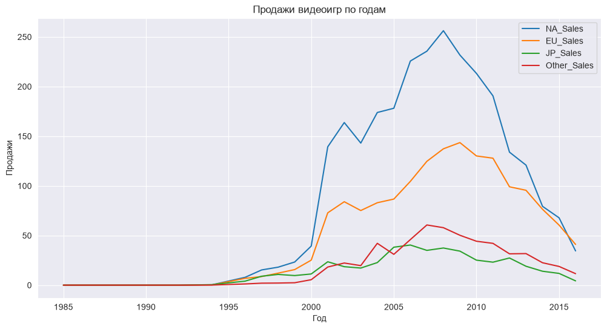

```python
# пункт 3.5
sales_by_year = games_data.groupby('Year_of_Release')[['NA_Sales', 'EU_Sales', 'JP_Sales', 'Other_Sales']].sum()

plt.figure(figsize=(12, 6))
plt.plot(sales_by_year.index, sales_by_year['NA_Sales'], label='NA_Sales')
plt.plot(sales_by_year.index, sales_by_year['EU_Sales'], label='EU_Sales')
plt.plot(sales_by_year.index, sales_by_year['JP_Sales'], label='JP_Sales')
plt.plot(sales_by_year.index, sales_by_year['Other_Sales'], label='Other_Sales')
plt.xlabel('Год')
plt.ylabel('Продажи')
plt.title('Продажи видеоигр по годам')
plt.legend()
plt.show()
```

**Задание 4**. С помощью библиотеки `seaborn` постройте распределение оценок критиков `Critic_Score` (рисунок 3) для датасета, загруженного в задании 3.

Рисунок 3 - Примерный результат

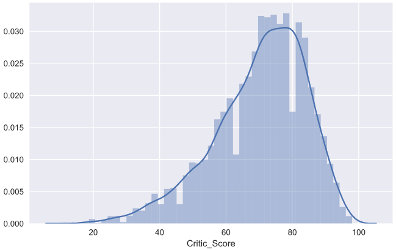

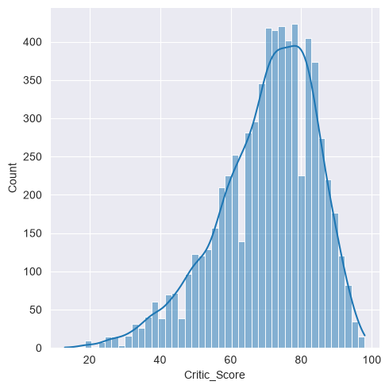

```python
# решение задания 4
sns.displot(games_data['Critic_Score'], kde=True)
plt.show()
```

**Задание 5**. Для того, чтобы подробнее посмотреть на взаимосвязь двух численных признаков, можно использовать **`joint_plot`** — это гибрид `scatter plot` и `histogram` (отображаются также гистограммы распределений признаков). Продемонстрируйте, как связаны между собой оценка критиков `Critic_Score` и оценка пользователя `User_Score` для датасета из задания 3.

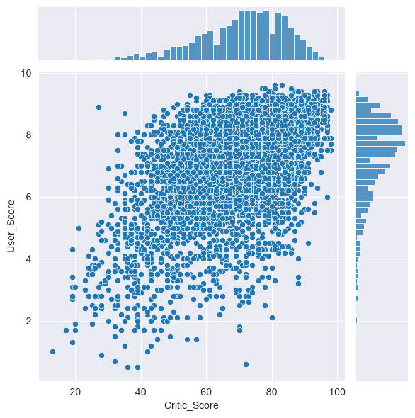

```python
# решение задания 5
sns.jointplot(data=games_data, x='Critic_Score', y='User_Score')
plt.show()
```

**Задание 6.** Для датасета из задания 3 постройте pair plot для следующих признаков: 'Global_Sales', 'Critic_Score', 'Critic_Count', 'User_Score', 'User_Count'

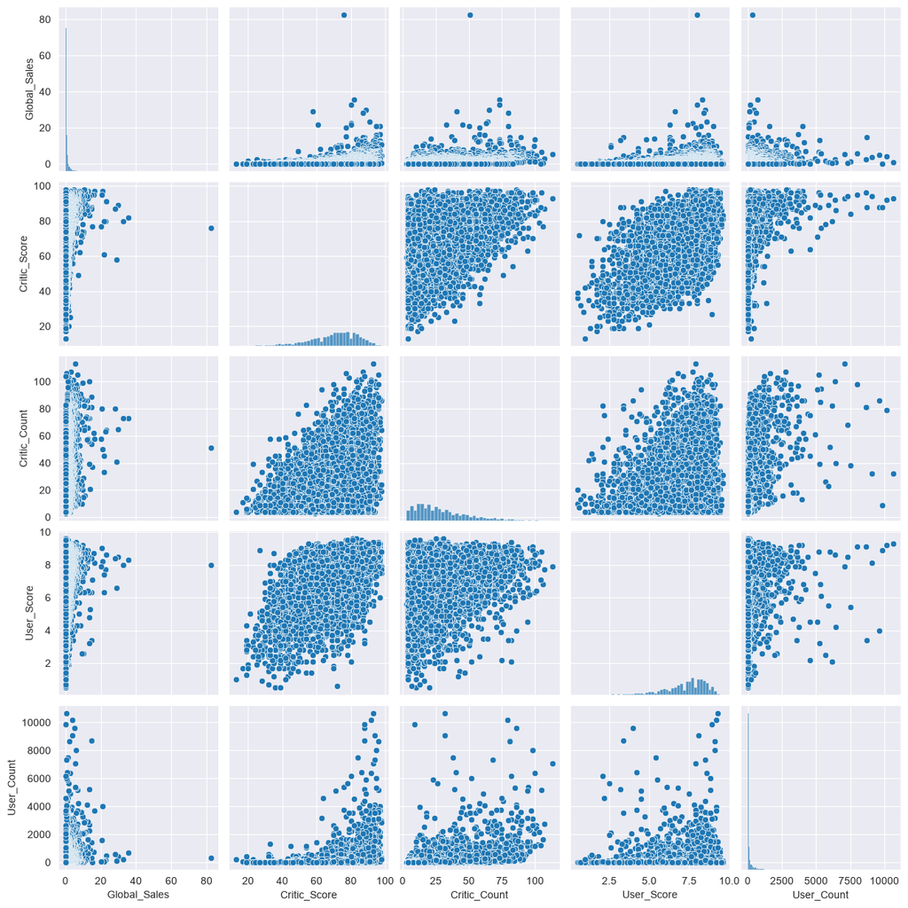

```python
# решение задания 6
pairplot_columns = ['Global_Sales', 'Critic_Score', 'Critic_Count', 'User_Score', 'User_Count']
sns.pairplot(games_data[pairplot_columns])
plt.show()
```